# Flight Price Prediction

## Dataset and attribute description

#### Attributes

1. Airline: The name of the airline company is stored in the airline column. It is a categorical feature having 6 different airlines.
2. Flight: Flight stores information regarding the plane's flight code. It is a categorical feature.
3. Source City: City from which the flight takes off. It is a categorical feature having 6 unique cities.
4. Departure Time: This is a derived categorical feature obtained created by grouping time periods into bins. It stores information about the departure time and have 6 unique time labels.
5. Stops: A categorical feature with 3 distinct values that stores the number of stops between the source and destination cities.
6. Arrival Time: This is a derived categorical feature created by grouping time intervals into bins. It has six distinct time labels and keeps information about the arrival time.
7. Destination City: City where the flight will land. It is a categorical feature having 6 unique cities.
8. Class: A categorical feature that contains information on seat class; it has two distinct values: Business and Economy.
9. Duration: A continuous feature that displays the overall amount of time it takes to travel between cities in hours.
10. Days Left: This is a derived characteristic that is calculated by subtracting the trip date by the booking date.
11. Price: Target variable stores information of the ticket price.

## EDA

In this section, I will clean and explore the dataset in order to answer the following:

- How does the ticket price vary between Economy and Business class?
- Does price vary with Airlines?
- How is the price affected when tickets are bought in just 1 or 2 days before departure?
- Does ticket price change based on the departure time and arrival time?
- How does ticket price change with changes in Source and Destination?
- Does the number of stops influence the price?

```python
import numpy as np
import pandas as pd
import matplotlib.pyplot as plt
import seaborn as sns
```

```python
import warnings
warnings.filterwarnings('ignore')
```

```python
data = pd.read_csv("https://raw.githubusercontent.com/julienjta/Data-Science-Portfolio/main/Project%201/data/dataset.csv",index_col=0)
```

```python
data.head()
```

|  | airline | flight | source_city | departure_time | stops | arrival_time | destination_city | class | duration | days_left | price |
| --- | --- | --- | --- | --- | --- | --- | --- | --- | --- | --- | --- |
| 0 | SpiceJet | SG-8709 | Delhi | Evening | zero | Night | Mumbai | Economy | 2.17 | 1 | 5953 |
| 1 | SpiceJet | SG-8157 | Delhi | Early_Morning | zero | Morning | Mumbai | Economy | 2.33 | 1 | 5953 |
| 2 | AirAsia | I5-764 | Delhi | Early_Morning | zero | Early_Morning | Mumbai | Economy | 2.17 | 1 | 5956 |
| 3 | Vistara | UK-995 | Delhi | Morning | zero | Afternoon | Mumbai | Economy | 2.25 | 1 | 5955 |
| 4 | Vistara | UK-963 | Delhi | Morning | zero | Morning | Mumbai | Economy | 2.33 | 1 | 5955 |

```python
data.shape
```

```
(300153, 11)
```

```python
data.info()
```

```
<class 'pandas.core.frame.DataFrame'>
Int64Index: 300153 entries, 0 to 300152
Data columns (total 11 columns):
 #   Column            Non-Null Count   Dtype
---  ------            --------------   -----
 0   airline           300153 non-null  object
 1   flight            300153 non-null  object
 2   source_city       300153 non-null  object
 3   departure_time    300153 non-null  object
 4   stops             300153 non-null  object
 5   arrival_time      300153 non-null  object
 6   destination_city  300153 non-null  object
 7   class             300153 non-null  object
 8   duration          300153 non-null  float64
 9   days_left         300153 non-null  int64
 10  price             300153 non-null  int64
dtypes: float64(1), int64(2), object(8)
memory usage: 27.5+ MB
```

```python
data.isnull().sum()
```

```
airline             0
flight              0
source_city         0
departure_time      0
stops               0
arrival_time        0
destination_city    0
class               0
duration            0
days_left           0
price               0
dtype: int64
```

```python
data.describe(include='all')
```

|  | airline | flight | source_city | departure_time | stops | arrival_time | destination_city | class | duration | days_left | price |
| --- | --- | --- | --- | --- | --- | --- | --- | --- | --- | --- | --- |
| count | 300153 | 300153 | 300153 | 300153 | 300153 | 300153 | 300153 | 300153 | 300153.000000 | 300153.000000 | 300153.000000 |
| unique | 6 | 1561 | 6 | 6 | 3 | 6 | 6 | 2 | NaN | NaN | NaN |
| top | Vistara | UK-706 | Delhi | Morning | one | Night | Mumbai | Economy | NaN | NaN | NaN |
| freq | 127859 | 3235 | 61343 | 71146 | 250863 | 91538 | 59097 | 206666 | NaN | NaN | NaN |
| mean | NaN | NaN | NaN | NaN | NaN | NaN | NaN | NaN | 12.221021 | 26.004751 | 20889.660523 |
| std | NaN | NaN | NaN | NaN | NaN | NaN | NaN | NaN | 7.191997 | 13.561004 | 22697.767366 |
| min | NaN | NaN | NaN | NaN | NaN | NaN | NaN | NaN | 0.830000 | 1.000000 | 1105.000000 |
| 25% | NaN | NaN | NaN | NaN | NaN | NaN | NaN | NaN | 6.830000 | 15.000000 | 4783.000000 |
| 50% | NaN | NaN | NaN | NaN | NaN | NaN | NaN | NaN | 11.250000 | 26.000000 | 7425.000000 |
| 75% | NaN | NaN | NaN | NaN | NaN | NaN | NaN | NaN | 16.170000 | 38.000000 | 42521.000000 |
| max | NaN | NaN | NaN | NaN | NaN | NaN | NaN | NaN | 49.830000 | 49.000000 | 123071.000000 |

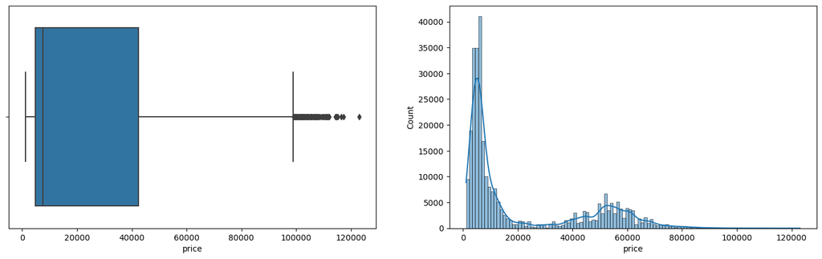

```python
plt.figure(figsize = (18,5))
plt.subplot(1,2,2)
sns.histplot(x = 'price', data = data, kde = True)
plt.subplot(1,2,1)
sns.boxplot(x= 'price', data = data)
```

We can see from the boxplot that the mean price is around 20000, though the median is about 7500. The distribute of the histogram shows two separate curves.

### Question 1: How do prices vary between each class (Business vs Economy)

To visualize the difference in price between Business and Economy, I'll color code each based on the airline.

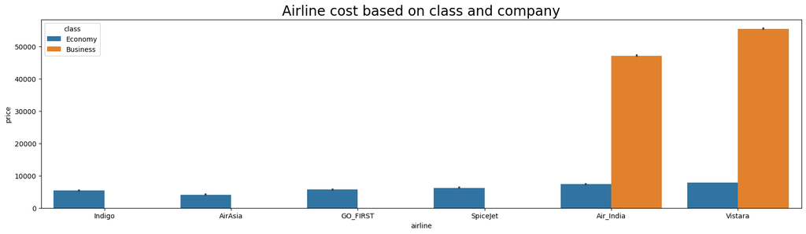

```python
plt.figure(figsize = (20,5))
sns.barplot(x = 'airline', y = 'price', hue = 'class', data = data.sort_values('price')).set_title('Airline cost based on class and company', fontsize = 20)
```

> Only Air India and Vistara offer Business class flights, at much higher prices than their Economy ticket counterparts.

### Question 2: Does price vary by airline?

Because some airlines do not offer Business class, I'll only evaluate Economy ticket prices

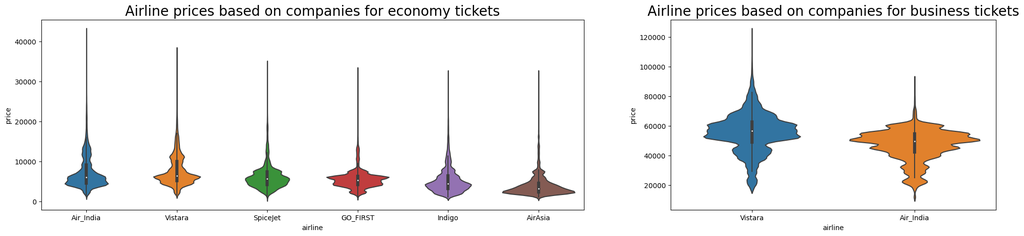

```python
fig, axs = plt.subplots (1, 2, gridspec_kw={'width_ratios': [5, 3]}, figsize=(25, 5))
sns.violinplot(y = "price", x = "airline",data = data.loc[data["class"]=='Economy'].sort_values("price", ascending = False), kind="boxen", ax=axs[0])
axs[0].set_title("Airline prices based on companies for economy tickets",fontsize=20)
sns.violinplot(y = "price", x = "airline",data = data.loc[data["class"]=='Business'].sort_values("price", ascending = False), kind="boxen", ax=axs[1])
axs[1].set_title("Airline prices based on companies for business tickets",fontsize=20)
```

> As we can see from the plots, AirAsia has the cheapest Economy flights, and Air India has the least expensive Business class flights

### Question 3: How is the price affected when tickets are bought in just 1 or 2 days before departure?

In order to determine how prices change depending on how far or close in advance tickets are purchased, I'll take the average price depending on days left before the flight.

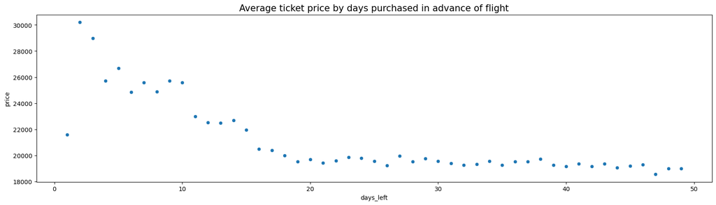

```python
data1 = data.groupby(['days_left'])['price'].mean().reset_index()

plt.figure(figsize = (20,5))
ax = sns.scatterplot(x = 'days_left', y = 'price', data = data1).set_title('Average ticket price by days purchased in advance of flight',
                                                                           fontsize = 15)
```

> The graph indicates that ticket prices increase as the flight approaches, but the trajectory of that increase changes at the 20-day mark. I'll parse this in the following graph.

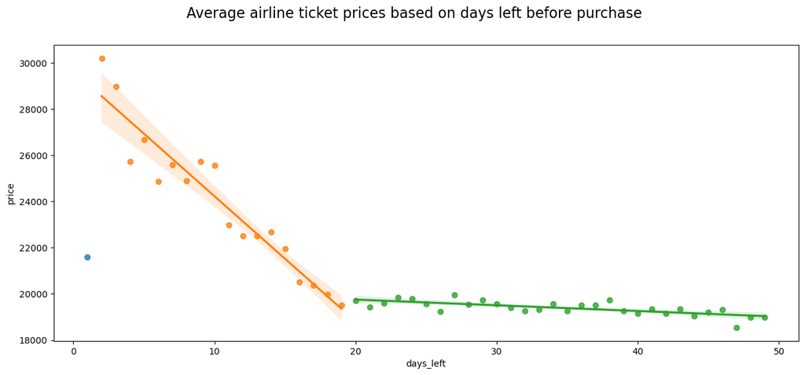

```python
plt.figure(figsize=(15,6)).suptitle('Average airline ticket prices based on days left before purchase', fontsize=16)
ax = plt.axes()
sns.regplot(x=data1.loc[data1["days_left"]==1].days_left, y=data1.loc[data1["days_left"]==1].price, fit_reg=False, ax=ax)
sns.regplot(x=data1.loc[(data1["days_left"]>1)&(data1["days_left"]<20)].days_left, y=data1.loc[(data1["days_left"]>1)&(data1["days_left"]<20)].price, fit_reg=True, ax=ax)
sns.regplot(x=data1.loc[data1["days_left"]>=20].days_left, y=data1.loc[data1["days_left"]>=20].price, fit_reg=True, ax=ax)
```

### Question 4: How does flight duration affect ticket price?

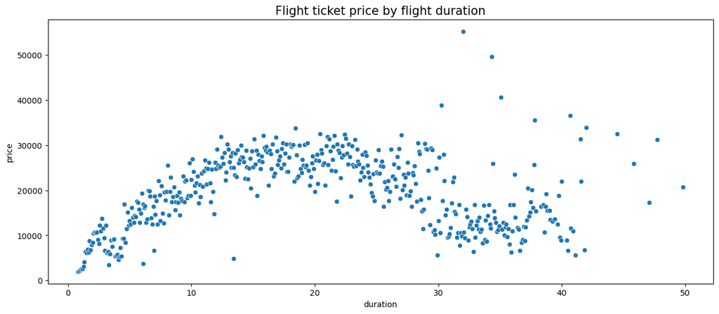

```python
data1 = data.groupby(['duration'])['price'].mean().reset_index()

plt.figure(figsize = (15,6))
ax = sns.scatterplot(x = 'duration', y = 'price', data = data1).set_title('Flight ticket price by flight duration', fontsize = 15)
```

> Now let's add a best fit line

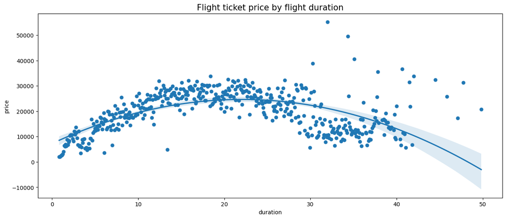

```python
plt.figure(figsize = (15,6))
ax = sns.scatterplot(x = 'duration', y = 'price', data = data1).set_title('Flight ticket price by flight duration', fontsize = 15)

ax = sns.regplot(x = 'duration', y = 'price', data = data1, order = 2)
```

> The duration-to-price line can be approximated as a quadratic curve, order 2. The curve peaks at around the 20 hour flight time mark.

### Question 5: Does ticket price change based on the departure time and arrival time?

Let's see how departure and arrival times affect prices.

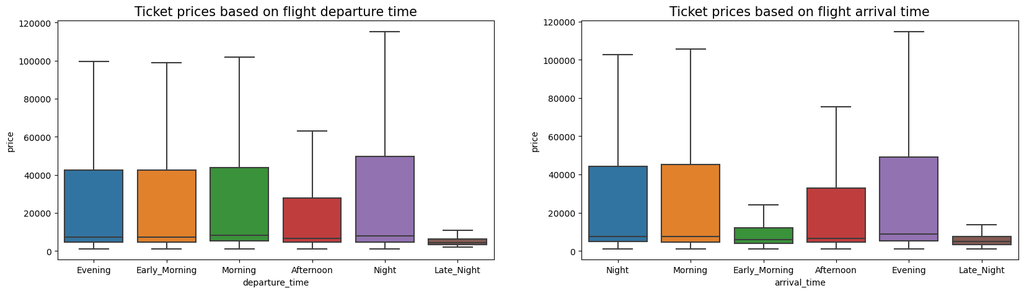

```python
plt.figure(figsize = (20,5))
plt.subplot(1,2,1)
sns.boxplot(x = 'departure_time', y = 'price', data = data, showfliers = False).set_title('Ticket prices based on flight departure time', fontsize=15)
plt.subplot(1,2,2)
sns.boxplot(x= 'arrival_time', y= 'price', data = data, showfliers = False).set_title('Ticket prices based on flight arrival time', fontsize = 15)
```

> As we can see, early morning and late night ticket prices tend to be the least expensive for arrivals, while night and evening departures tend to be the most expensive for departures and arrivals.

### Question 6: Does ticket price change based on the departure and arrival cities?

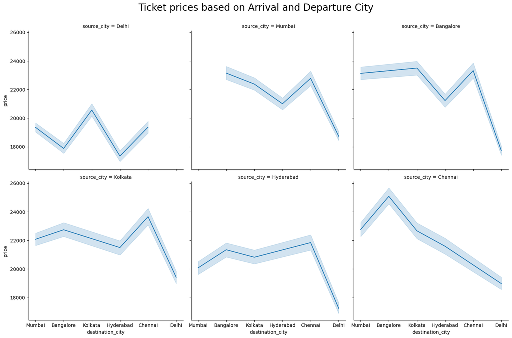

```python
ax = sns.relplot(data = data, col = 'source_city', x = 'destination_city', y = 'price', kind = 'line', col_wrap = 3)
ax.fig.subplots_adjust(top = .9)
ax.fig.suptitle('Ticket prices based on Arrival and Departure City', fontsize = 20)
```

### Question 7: Does the number of stops influence the price?

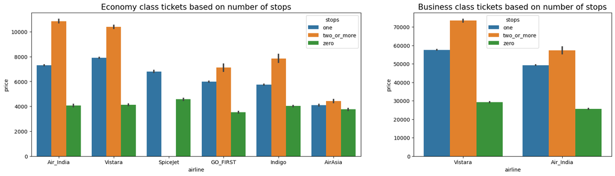

```python
fig, axs = plt.subplots(1,2, gridspec_kw = {'width_ratios' : [5,3]}, figsize = (20,5))
sns.barplot(data = data.loc[data['class']=='Economy'].sort_values('price', ascending = False), x = 'airline', y = 'price', hue = 'stops', ax = axs[0])
axs[0].set_title('Economy class tickets based on number of stops', fontsize = 15)
sns.barplot(data = data.loc[data['class']=='Business'].sort_values('price', ascending = False), x = 'airline', y = 'price', hue = 'stops', ax = axs[1])
axs[1].set_title('Business class tickets based on number of stops', fontsize = 15)
```

> For each airline, more stops tends to translate to higher ticket prices, while non-stop flights tend to be least expensive. For AirAsia, though, ticket prices tend to be constant regardless of number of stops.

### Key insights from EDA

- Business class flights are more expensive than economy class flights, and a major predictor of ticket price
- Flights around the 20-hr mark are the peak of expensive flights, as flights longer than 20 hours decrease in price.
- Flights become more expensive as the day of flight approaches
- Late night departures and arrivals are least expensive, and night departures are most expensive

## Price Predictions

```python
final_data = pd.read_csv('https://raw.githubusercontent.com/julienjta/Data-Science-Portfolio/main/Project%201/data/dataset.csv',index_col=0)
```

```python
final_data.head()
```

|  | airline | flight | source_city | departure_time | stops | arrival_time | destination_city | class | duration | days_left | price |
| --- | --- | --- | --- | --- | --- | --- | --- | --- | --- | --- | --- |
| 0 | SpiceJet | SG-8709 | Delhi | Evening | zero | Night | Mumbai | Economy | 2.17 | 1 | 5953 |
| 1 | SpiceJet | SG-8157 | Delhi | Early_Morning | zero | Morning | Mumbai | Economy | 2.33 | 1 | 5953 |
| 2 | AirAsia | I5-764 | Delhi | Early_Morning | zero | Early_Morning | Mumbai | Economy | 2.17 | 1 | 5956 |
| 3 | Vistara | UK-995 | Delhi | Morning | zero | Afternoon | Mumbai | Economy | 2.25 | 1 | 5955 |
| 4 | Vistara | UK-963 | Delhi | Morning | zero | Morning | Mumbai | Economy | 2.33 | 1 | 5955 |

##### Importing packages

```python
from sklearn.model_selection import KFold, cross_val_predict, GridSearchCV, train_test_split
from sklearn.preprocessing import PolynomialFeatures, StandardScaler, LabelEncoder
from sklearn.linear_model import LinearRegression, LassoCV, RidgeCV, ElasticNetCV
from sklearn.pipeline import Pipeline
from sklearn.metrics import r2_score
```

```python
for i in final_data.select_dtypes('object').columns:
    encoder = LabelEncoder()
    final_data[i] = encoder.fit_transform(final_data[i])
```

```python
final_data.drop('flight', axis=1, inplace=True)
```

```python
final_data
```

|  | airline | source_city | departure_time | stops | arrival_time | destination_city | class | duration | days_left | price |
| --- | --- | --- | --- | --- | --- | --- | --- | --- | --- | --- |
| 0 | 4 | 2 | 2 | 2 | 5 | 5 | 1 | 2.17 | 1 | 5953 |
| 1 | 4 | 2 | 1 | 2 | 4 | 5 | 1 | 2.33 | 1 | 5953 |
| 2 | 0 | 2 | 1 | 2 | 1 | 5 | 1 | 2.17 | 1 | 5956 |
| 3 | 5 | 2 | 4 | 2 | 0 | 5 | 1 | 2.25 | 1 | 5955 |
| 4 | 5 | 2 | 4 | 2 | 4 | 5 | 1 | 2.33 | 1 | 5955 |
| ... | ... | ... | ... | ... | ... | ... | ... | ... | ... | ... |
| 300148 | 5 | 1 | 4 | 0 | 2 | 3 | 0 | 10.08 | 49 | 69265 |
| 300149 | 5 | 1 | 0 | 0 | 5 | 3 | 0 | 10.42 | 49 | 77105 |
| 300150 | 5 | 1 | 1 | 0 | 5 | 3 | 0 | 13.83 | 49 | 79099 |
| 300151 | 5 | 1 | 1 | 0 | 2 | 3 | 0 | 10.00 | 49 | 81585 |
| 300152 | 5 | 1 | 4 | 0 | 2 | 3 | 0 | 10.08 | 49 | 81585 |

300153 rows × 10 columns

##### Train/test split

```python
X = final_data.drop('price', axis = 1)
y = final_data.price
```

```python
kf = KFold(shuffle=True, random_state=42, n_splits=3)
```

```python
kf.split(X)
```

```
<generator object _BaseKFold.split at 0x00000158BBA58D60>
```

```python
X.shape
```

```
(300153, 9)
```

### Simple Linear model

```python
s = StandardScaler()
lr = LinearRegression()
estimator = Pipeline([('scaler', s), ('regression', lr)])
predictions = cross_val_predict(estimator, X, y, cv = kf)
```

```python
linear_r2 = r2_score(y, predictions)
print('R2 score of polynomial linear regression is', linear_r2)
```

```
R2 score of polynomial linear regression is 0.9045994744346403
```

### Linear model with polynomial features

```python
pf = PolynomialFeatures()
estimator2 = Pipeline([('poly', pf), ('scaler', s), ('regression', lr)])
parameters = {'poly__degree': np.arange(2,5)}

grid1 = GridSearchCV(estimator2, parameters, cv = kf)
```

```python
grid1.fit(X, y)
```

```
GridSearchCV(cv=KFold(n_splits=3, random_state=42, shuffle=True),
             estimator=Pipeline(steps=[('poly', PolynomialFeatures()),
                                       ('scaler', StandardScaler()),
                                       ('regression', LinearRegression())]),
             param_grid={'poly__degree': array([2, 3, 4])})
```

```python
print('Optimal degrees of polynomial linear regression is', grid1.best_params_['poly__degree'])

estimator2 = grid1.best_estimator_
y_pred = estimator2.predict(X)

poly_r2 = r2_score(y, y_pred)

print('R2 score of polynomial linear regression is', poly_r2)
```

```
Optimal degrees of polynomial linear regression is 4
R2 score of polynomial linear regression is 0.9538909042564874
```

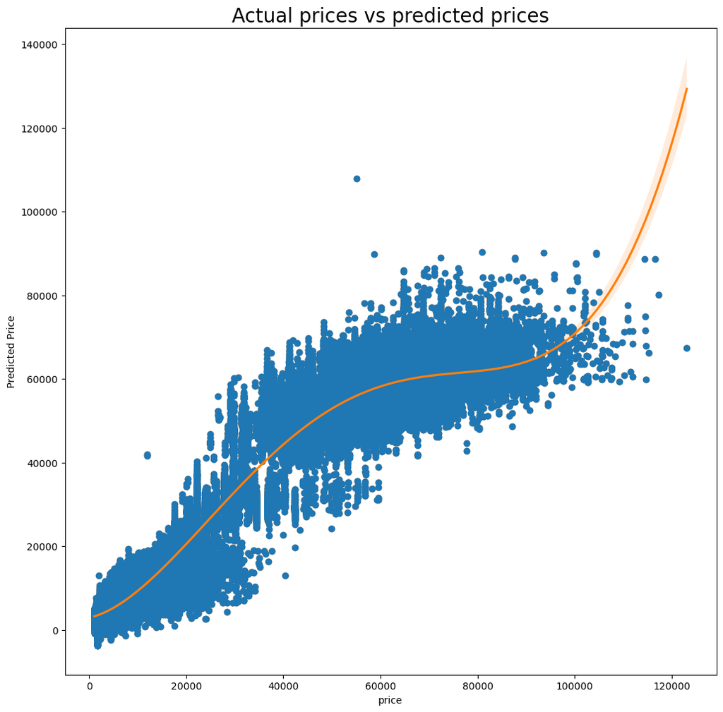

```python
from matplotlib.pyplot import xlabel


f = plt.figure(figsize= (12,12))
ax = plt.axes()

ax.plot(y, y_pred, marker = 'o', ls = '')

lim = (0, y_pred.max())

ax.set(xlabel = 'Actual Price',ylabel = 'Predicted Price', title = 'Polynomial regression results')

ax = sns.regplot(x = y, y = y_pred, data= final_data, order = 4).set_title('Actual prices vs predicted prices', fontsize = 20)
```

## Summary of findings

### Key insights from model predictions

- The Polynomial models is better model of predictor of price with an $ r^{2} $ score of about 95.3%
- The linear model is the worst predictor of price

### Future directions

- Using more complex regression models may yield higher $ r^{2} $ scores, such as a stack blend or Decision Tree.
- Predicting price for both the economy and business class tickets, as the class seems to be a major predictor of price